# Notebook

```python
from matplotlib import pyplot as plt
import numpy as np
import pandas as pd
import geopandas as gpd
import altair as alt
```

```python
pd.options.display.max_columns = 999
```

```python
plt.rcParams['figure.figsize'] = (10,6)
```

## Week 9A: OpenStreetMap, Urban Networks, and Interactive Web Maps

Nov 1, 2021

# Happy day after Halloween

[figure not shown]

## Housekeeping

- HW #4 (optional) due today by the end of the day
- HW #5 (optional) posted last Wednesday — due on Wed Nov. 10
- Final project details posted: https://github.com/MUSA-550-Fall-2021/final-project

## Important: Update your local environment

- Small update to course's Python environment relevant to today's lecture
- Update the environment on your laptop using [these instructions](https://musa-550-fall-2021.github.io/guides/conda#updating-an-existing-environment) on course website

## Today: OpenStreetMap (OSM)

- Two tools that make working with OSM data very easy
- What kind of questions can we answer?
  - Street orientations
  - Mapping event points to streets: car crashes
  - Mapping amenities
  - Network-constrained distances: accessibility

## OSM: what is it?

- Collaborative mapping
- A free editable map of the World
- Sort of like Wikipedia for maps

**Great source of data: street networks and a wealth of amenity information**

https://www.openstreetmap.org

## Working with OSM data

- Raw data is very messy
- Two relatively new, amazing Python packages greatly simply the process
- Related, but complementary features
  - **OSMnx:** downloading and manipulating streets as networks
  - **Pandana:** networks focused on accessibility of amenities

**Related:** interactive web maps in Python

## Part 1: OSMnx

Several key features:

- Downloading political boundaries for cities, states, countries, etc
- Downloading street networks
- Analyzing networks: routing, visualization, statistics
- [GitHub](https://github.com/gboeing/osmnx)
- [Introductory Blog Post](https://geoffboeing.com/2016/11/osmnx-python-street-networks/)
- [Jupyter Notebook Examples](https://github.com/gboeing/osmnx-examples/tree/master/notebooks) ([Binder](https://mybinder.org/v2/gh/gboeing/osmnx-examples/main?urlpath=/tree/notebooks))
- [Documentation](https://osmnx.readthedocs.io)

```python
import osmnx as ox
```

## 1.1. Getting boundary shapefiles from OSM

Key function: `geocode_to_gdf()` ([docs](https://osmnx.readthedocs.io/en/stable/osmnx.html#osmnx.geocoder.geocode_to_gdf))

We can get the boundary for anything identified as a "place" by OSM.

**Important: Be careful to pass the right place name that OSM needs**

```python
philly = ox.geocode_to_gdf('Philadelphia, PA, USA')
philly.head()
```

|  | geometry | bbox_north | bbox_south | bbox_east | bbox_west | place_id | osm_type | osm_id | lat | lon | display_name | class | type | importance |
| --- | --- | --- | --- | --- | --- | --- | --- | --- | --- | --- | --- | --- | --- | --- |
| 0 | POLYGON ((-75.28030 39.97500, -75.28022 39.974... | 40.137959 | 39.867005 | -74.955831 | -75.280298 | 282365563 | relation | 188022 | 39.952724 | -75.163526 | Philadelphia, Philadelphia County, Pennsylvani... | boundary | administrative | 0.823797 |

We can plot it just like any other GeoDataFrame

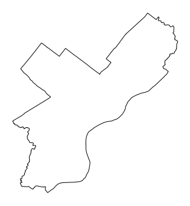

```python
# Project it to Web Mercator first and plot
ax = philly.to_crs(epsg=3857).plot(facecolor='none', edgecolor='black')
ax.set_axis_off()
```

## 1.2 Projecting with OSMnx

Key function: `project_gdf()` ([docs](https://osmnx.readthedocs.io/en/stable/osmnx.html#osmnx.projection.project_gdf))

Automatically projects to the [Universal Transverse Mercator](https://en.wikipedia.org/wiki/Universal_Transverse_Mercator_coordinate_system) (UTM) CRS for the UTM zone that the centroid of the polygon lies in

A good, general projection that works for most latitudes except very northern locations.

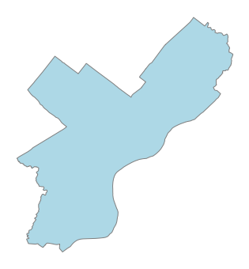

```python
ax = ox.project_gdf(philly).plot(fc="lightblue", ec="gray")
ax.set_axis_off()
```

Some more examples:

```python
# Some examples
place1 = ox.geocode_to_gdf('Manhattan, New York City, New York, USA')
place2 = ox.geocode_to_gdf('Miami-Dade County, Florida')
place3 = ox.geocode_to_gdf('Florida, USA')
place4 = ox.geocode_to_gdf('Spain')
```

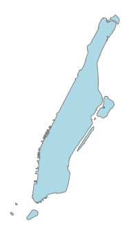

```python
# Manhattan
ax = ox.project_gdf(place1).plot(fc="lightblue", ec="gray");
ax.set_axis_off()
```

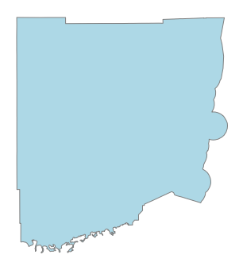

```python
# Miami-Dade County
ax = ox.project_gdf(place2).plot(fc="lightblue", ec="gray")
ax.set_axis_off()
```

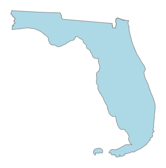

```python
# Florida
ax = ox.project_gdf(place3).plot(fc="lightblue", ec="gray")
ax.set_axis_off()
```

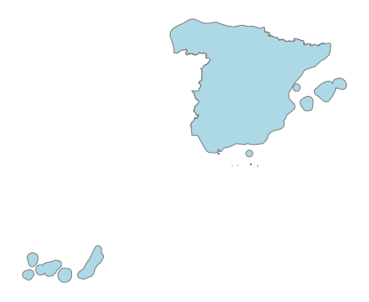

```python
# Spain
ax = ox.project_gdf(place4).plot(fc="lightblue", ec="gray")
ax.set_axis_off()
```

## 1.3 Downloading OSM features

Key functions: `geometries_from_*`

- `geometries_from_place()` ([docs](https://osmnx.readthedocs.io/en/stable/osmnx.html#osmnx.geometries.geometries_from_place))
  - Download geometries within an OSM place boundary
- `geometries_from_address()` ([docs](https://osmnx.readthedocs.io/en/stable/osmnx.html#osmnx.geometries.geometries_from_address))
  - Download geometries within a certain distance of an address
- `geometries_from_bbox()` ([docs](https://osmnx.readthedocs.io/en/stable/osmnx.html#osmnx.geometries.geometries_from_bbox))
  - Download geometries within a N, S, E, W bounding box
- `geometries_from_point()` ([docs](https://osmnx.readthedocs.io/en/stable/osmnx.html#osmnx.geometries.geometries_from_point))
  - Download geometries within a certain distance of a specified point
- `geometries_from_polygon()` ([docs](https://osmnx.readthedocs.io/en/stable/osmnx.html#osmnx.geometries.geometries_from_polygon))
  - Download geometries within a polygon object

### About OSM features

**Important reference:** https://wiki.openstreetmap.org/wiki/Map_Features

- OSM uses a *tagging* system to categorize different map features
- The main feature categories are available on the OSM Wikipedia
  - Examples: 'amenity', 'building', 'landuse', 'highway'
- There are specific sub-categories for each feature type too:
  - Amenity examples: 'bar', 'college', 'library'

In the language of OSM, the "key" is the main feature category (e.g., amenity) and the "value" is the sub-category type (e.g., "bar")

### OSMnx mirrors the key/value syntax

Use a dict to specify the features you want:

```python
# Get all amenities in Philadelphia
amenities = ox.geometries_from_place("Philadelphia, PA", tags={"amenity": True})

len(amenities)
```

```
9157
```

```python
amenities.head()
```

| element_type | osmid | highway | geometry | amenity | created_by | cuisine | name | shop | addr:city | addr:postcode | wheelchair | addr:housenumber | addr:state | addr:street | brand | brand:wikidata | brand:wikipedia | official_name | opening_hours | phone | takeaway | source | healthcare | short_name | internet_access | url | contact:phone | description | email | … |
| --- | --- | --- | --- | --- | --- | --- | --- | --- | --- | --- | --- | --- | --- | --- | --- | --- | --- | --- | --- | --- | --- | --- | --- | --- | --- | --- | --- | --- | --- | --- |
| node | 109811385 | NaN | POINT (-75.19487 40.05846) | bench | NaN | NaN | NaN | NaN | NaN | NaN | NaN | NaN | NaN | NaN | NaN | NaN | NaN | NaN | NaN | NaN | NaN | NaN | NaN | NaN | NaN | NaN | NaN | NaN | NaN | … |
|  | 109993125 | traffic_signals | POINT (-75.19107 40.06019) | pub | NaN | NaN | NaN | NaN | NaN | NaN | NaN | NaN | NaN | NaN | NaN | NaN | NaN | NaN | NaN | NaN | NaN | NaN | NaN | NaN | NaN | NaN | NaN | NaN | NaN | … |
|  | 274215467 | NaN | POINT (-75.19492 39.95935) | fast_food | Potlatch 0.9c | pizza | Powelton Pizza | NaN | NaN | NaN | NaN | NaN | NaN | NaN | NaN | NaN | NaN | NaN | NaN | NaN | NaN | NaN | NaN | NaN | NaN | NaN | NaN | NaN | NaN | … |
|  | 274216093 | NaN | POINT (-75.19126 39.95765) | atm | NaN | NaN | Citi Bank | convenience | NaN | NaN | NaN | NaN | NaN | NaN | NaN | NaN | NaN | NaN | NaN | NaN | NaN | NaN | NaN | NaN | NaN | NaN | NaN | NaN | NaN | … |
|  | 274216582 | NaN | POINT (-75.20081 39.95476) | pub | Potlatch 0.9c | NaN | The Blarney Stone | NaN | NaN | NaN | NaN | NaN | NaN | NaN | NaN | NaN | NaN | NaN | NaN | NaN | NaN | NaN | NaN | NaN | NaN | NaN | NaN | NaN | NaN | … |

```python
# Get all bars in philadelphia
bars = ox.geometries_from_place("Philadelphia, PA", tags={"amenity": "bar"})

len(bars)
```

```
151
```

```python
bars.head()
```

| element_type | osmid | addr:city | addr:housenumber | addr:postcode | addr:state | addr:street | amenity | brewery | craft | gnis:county_id | microbrewery | name | operator | restaurant | website | wikidata | wikipedia | geometry | opening_hours | phone | smoking | toilets:wheelchair | wheelchair | addr:housename | designation | source | wifi | leisure | sport | … |
| --- | --- | --- | --- | --- | --- | --- | --- | --- | --- | --- | --- | --- | --- | --- | --- | --- | --- | --- | --- | --- | --- | --- | --- | --- | --- | --- | --- | --- | --- | --- |
| node | 357303425 | Philadelphia | 500 | 19123 | PA | Spring Garden Street | bar | yes | brewery | 101 | yes | Yards Brewing Company | Yards Brewing Company | yes | https://yardsbrewing.com/ | Q16903914 | en:Yards Brewing Company | POINT (-75.14712 39.96067) | NaN | NaN | NaN | NaN | NaN | NaN | NaN | NaN | NaN | NaN | NaN | … |
|  | 655425272 | NaN | NaN | NaN | NaN | NaN | bar | NaN | NaN | NaN | NaN | Drinkers West | NaN | NaN | NaN | NaN | NaN | POINT (-75.20020 39.95521) | NaN | NaN | NaN | NaN | NaN | NaN | NaN | NaN | NaN | NaN | NaN | … |
|  | 1167079387 | NaN | NaN | NaN | NaN | NaN | bar | NaN | NaN | NaN | NaN | Milkboy | NaN | NaN | NaN | NaN | NaN | POINT (-75.14925 39.94170) | NaN | NaN | NaN | NaN | NaN | NaN | NaN | NaN | NaN | NaN | NaN | … |
|  | 1204761128 | NaN | NaN | NaN | NaN | NaN | bar | NaN | NaN | NaN | NaN | Vikings High School Club | NaN | NaN | NaN | NaN | NaN | POINT (-75.16363 39.92685) | NaN | NaN | NaN | NaN | NaN | NaN | NaN | NaN | NaN | NaN | NaN | … |
|  | 1424271155 | NaN | 344 | 19147 | NaN | South Street | bar | NaN | NaN | NaN | NaN | Copabanana | NaN | NaN | http://copabanana.com/ | NaN | NaN | POINT (-75.14909 39.94152) | Mo-Su 11:30-02:00 | +1 215 9236180 | NaN | NaN | NaN | NaN | NaN | NaN | NaN | NaN | NaN | … |

```python
# Get bar, pub, and restaurant features in Philadelphia
food_and_drink = ox.geometries_from_place("Philadelphia, PA", tags={"amenity": ["pub", "bar", "restaurant"]})

len(food_and_drink)
```

```
982
```

```python
food_and_drink.head()
```

| element_type | osmid | amenity | highway | geometry | created_by | name | addr:city | addr:postcode | wheelchair | source | addr:housenumber | addr:state | addr:street | brewery | opening_hours | craft | gnis:county_id | microbrewery | operator | restaurant | website | wikidata | wikipedia | cuisine | outdoor_seating | phone | diet:vegetarian | description | addr:housename | … |
| --- | --- | --- | --- | --- | --- | --- | --- | --- | --- | --- | --- | --- | --- | --- | --- | --- | --- | --- | --- | --- | --- | --- | --- | --- | --- | --- | --- | --- | --- | --- |
| node | 109993125 | pub | traffic_signals | POINT (-75.19107 40.06019) | NaN | NaN | NaN | NaN | NaN | NaN | NaN | NaN | NaN | NaN | NaN | NaN | NaN | NaN | NaN | NaN | NaN | NaN | NaN | NaN | NaN | NaN | NaN | NaN | NaN | … |
|  | 274216582 | pub | NaN | POINT (-75.20081 39.95476) | Potlatch 0.9c | The Blarney Stone | NaN | NaN | NaN | NaN | NaN | NaN | NaN | NaN | NaN | NaN | NaN | NaN | NaN | NaN | NaN | NaN | NaN | NaN | NaN | NaN | NaN | NaN | NaN | … |
|  | 274216619 | pub | NaN | POINT (-75.19994 39.95446) | NaN | Cavanaugh's | Philadelphia | 19104 | limited | NaN | NaN | NaN | NaN | NaN | NaN | NaN | NaN | NaN | NaN | NaN | NaN | NaN | NaN | NaN | NaN | NaN | NaN | NaN | NaN | … |
|  | 274216804 | pub | NaN | POINT (-75.19844 39.95571) | Potlatch 0.9c | Brownie's 38th St. | NaN | NaN | NaN | NaN | NaN | NaN | NaN | NaN | NaN | NaN | NaN | NaN | NaN | NaN | NaN | NaN | NaN | NaN | NaN | NaN | NaN | NaN | NaN | … |
|  | 333786044 | restaurant | NaN | POINT (-75.15893 39.94086) | Potlatch 0.10f | Sam's Morning Glory | NaN | NaN | limited | knowledge | NaN | NaN | NaN | NaN | NaN | NaN | NaN | NaN | NaN | NaN | NaN | NaN | NaN | NaN | NaN | NaN | NaN | NaN | NaN | … |

```python
# Get higway bus stop features
bus_stops = ox.geometries_from_place("Philadelphia, PA", tags={"highway": "bus_stop"})

len(bus_stops)
```

```
249
```

```python
bus_stops.head()
```

| element_type | osmid | bus | highway | public_transport | geometry | bench | covered | name | network | operator | shelter | ref | tactile_paving | wheelchair | route_ref | local_ref | designation | source | departures_board | bin | lit | internet_access | addr:street | route_ref_1 | note | operator:wikidata | brand | brand:wikidata | railway | … |
| --- | --- | --- | --- | --- | --- | --- | --- | --- | --- | --- | --- | --- | --- | --- | --- | --- | --- | --- | --- | --- | --- | --- | --- | --- | --- | --- | --- | --- | --- | --- |
| node | 109812837 | yes | bus_stop | platform | POINT (-75.19363 40.05964) | NaN | NaN | NaN | NaN | NaN | NaN | NaN | NaN | NaN | NaN | NaN | NaN | NaN | NaN | NaN | NaN | NaN | NaN | NaN | NaN | NaN | NaN | NaN | NaN | … |
|  | 361011456 | yes | bus_stop | platform | POINT (-75.16166 39.95223) | yes | yes | 13th St & Market St | SEPTA | SEPTA | yes | NaN | NaN | NaN | NaN | NaN | NaN | NaN | NaN | NaN | NaN | NaN | NaN | NaN | NaN | NaN | NaN | NaN | NaN | … |
|  | 750281693 | yes | bus_stop | platform | POINT (-75.07732 40.01797) | NaN | NaN | NaN | NaN | NaN | NaN | NaN | NaN | NaN | NaN | NaN | NaN | NaN | NaN | NaN | NaN | NaN | NaN | NaN | NaN | NaN | NaN | NaN | NaN | … |
|  | 768271130 | yes | bus_stop | platform | POINT (-75.20726 40.01487) | NaN | NaN | Wissahickon Transportation Center | NaN | SEPTA | yes | NaN | NaN | NaN | NaN | NaN | NaN | NaN | NaN | NaN | NaN | NaN | NaN | NaN | NaN | NaN | NaN | NaN | NaN | … |
|  | 1015342921 | yes | bus_stop | platform | POINT (-75.18187 39.96640) | NaN | NaN | NaN | NaN | NaN | NaN | NaN | NaN | NaN | NaN | NaN | NaN | NaN | NaN | NaN | NaN | NaN | NaN | NaN | NaN | NaN | NaN | NaN | NaN | … |

```python
# Get commercial and retail landuse features
landuse = ox.geometries_from_place("Philadelphia, PA", tags={"landuse": ["commercial", "retail"]})

len(landuse)
```

```
172
```

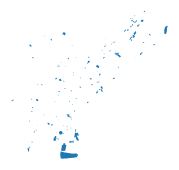

```python
fig, ax = plt.subplots(figsize=(10, 6))

ax = landuse.plot(ax=ax)
ax.set_axis_off()
```

## 1.4 Downloading street networks

Key functions: `graph_from_*`

- `graph_from_place()` ([docs](https://osmnx.readthedocs.io/en/stable/osmnx.html#osmnx.graph.graph_from_place))
  - Download street network within an OSM place boundary
- `graph_from_address()` ([docs](https://osmnx.readthedocs.io/en/stable/osmnx.html#osmnx.graph.graph_from_address))
  - Download street network within a certain distance of an address
- `graph_from_bbox()` ([docs](https://osmnx.readthedocs.io/en/stable/osmnx.html#osmnx.graph.graph_from_bbox))
  - Download street network within a N, S, E, W bounding box
- `graph_from_point()` ([docs](https://osmnx.readthedocs.io/en/stable/osmnx.html#osmnx.graph.graph_from_point))
  - Download street network within a certain distance of a specified point
- `graph_from_polygon()` ([docs](https://osmnx.readthedocs.io/en/stable/osmnx.html#osmnx.graph.graph_from_polygon))
  - Download street network within a polygon object

### Street network around an address

Get streets within 500 meters of the center of Northern Liberties

```python
G = ox.graph_from_address("Northern Liberties, Philadelphia, PA", dist=500)
```

Project and plot it:

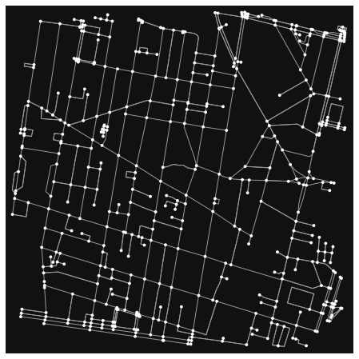

```python
G_projected = ox.project_graph(G)
ox.plot_graph(G_projected);
```

Remove the nodes:

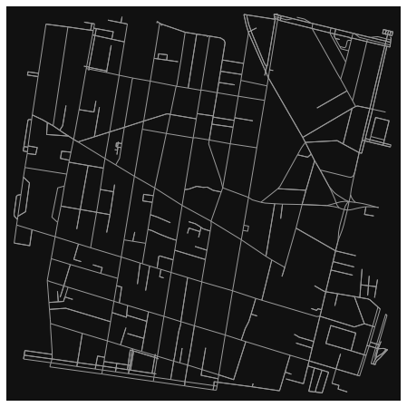

```python
ox.plot_graph(G_projected, node_size=0);
```

Let's zoom out to 2,000 meters. This will take a little longer.

```python
G = ox.graph_from_address("Northern Liberties, Philadelphia, PA", dist=2000)
G_projected = ox.project_graph(G)
```

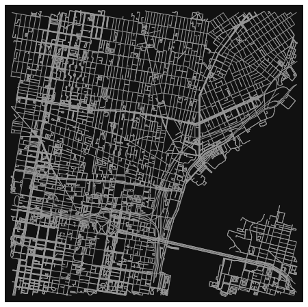

```python
ox.plot_graph(G_projected, node_size=0);
```

### Getting different network types

- `drive` - get drivable public streets (but not service roads)
- `drive_service` - get drivable streets, including service roads
- `walk` - get all streets and paths that pedestrians can use (this network type ignores one-way directionality)
- `bike` - get all streets and paths that cyclists can use
- `all` - download all non-private OSM streets and paths
- `all_private` - download all OSM streets and paths, including private-access ones (default)

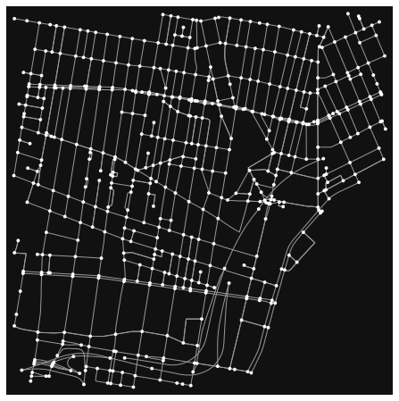

```python
# the "drive" network
G = ox.graph_from_address("Northern Liberties, Philadelphia, PA",
                          network_type='drive')
ox.plot_graph(G);
```

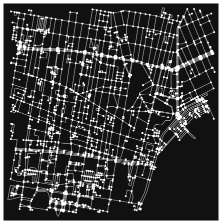

```python
# the "walk" network
G = ox.graph_from_address("Northern Liberties, Philadelphia, PA",
                           network_type='walk')
ox.plot_graph(ox.project_graph(G));
```

### Street network within a place boundary

Use `graph_from_place()` to get the streets within a specific OSM place.

**Note: the place query has to be resolved by OSM.**

```python
berkeley = ox.graph_from_place("Berkeley, California, USA",)
```

[figure not shown]

```python
ox.plot_graph(ox.project_graph(berkeley), node_size=0);
```

### Streets within a specific polygon

**Example:** all streets within Northern Liberties and Fishtown

### First, let's wrangle some Zillow neighborhood boundaries

```python
url = "https://github.com/azavea/geo-data/raw/master/Neighborhoods_Philadelphia/Neighborhoods_Philadelphia.geojson"
hoods = gpd.read_file(url).rename(columns={"mapname": "neighborhood"})
```

```python
hoods.head()
```

|  | name | listname | neighborhood | shape_leng | shape_area | cartodb_id | created_at | updated_at | geometry |
| --- | --- | --- | --- | --- | --- | --- | --- | --- | --- |
| 0 | PENNYPACK_PARK | Pennypack Park | Pennypack Park | 87084.285589 | 6.014076e+07 | 9 | 2013-03-19T17:41:50.507999+00:00 | 2013-03-19T17:41:50.743000+00:00 | MULTIPOLYGON (((-75.05645 40.08743, -75.05667 ... |
| 1 | OVERBROOK | Overbrook | Overbrook | 57004.924607 | 7.692499e+07 | 138 | 2013-03-19T17:41:50.507999+00:00 | 2013-03-19T17:41:50.743000+00:00 | MULTIPOLYGON (((-75.22719 39.97740, -75.22984 ... |
| 2 | GERMANTOWN_SOUTHWEST | Germantown, Southwest | Southwest Germantown | 14880.743608 | 1.441867e+07 | 59 | 2013-03-19T17:41:50.507999+00:00 | 2013-03-19T17:41:50.743000+00:00 | MULTIPOLYGON (((-75.16208 40.02829, -75.16145 ... |
| 3 | EAST_PARKSIDE | East Parkside | East Parkside | 10885.781535 | 4.231000e+06 | 129 | 2013-03-19T17:41:50.507999+00:00 | 2013-03-19T17:41:50.743000+00:00 | MULTIPOLYGON (((-75.19931 39.97462, -75.19869 ... |
| 4 | GERMANY_HILL | Germany Hill | Germany Hill | 13041.939087 | 6.949968e+06 | 49 | 2013-03-19T17:41:50.507999+00:00 | 2013-03-19T17:41:50.743000+00:00 | MULTIPOLYGON (((-75.22722 40.03523, -75.22865 ... |

Trim to Fishtown and Northern Liberties

```python
sel = hoods['neighborhood'].isin(['Fishtown - Lower Kensington', 'Northern Liberties'])
nolibs_fishtown = hoods.loc[sel]
```

```python
nolibs_fishtown.head()
```

|  | name | listname | neighborhood | shape_leng | shape_area | cartodb_id | created_at | updated_at | geometry |
| --- | --- | --- | --- | --- | --- | --- | --- | --- | --- |
| 105 | FISHTOWN | Fishtown - Lower Kensington | Fishtown - Lower Kensington | 25973.395800 | 3.360583e+07 | 87 | 2013-03-19T17:41:50.507999+00:00 | 2013-03-19T17:41:50.743000+00:00 | MULTIPOLYGON (((-75.12718 39.96086, -75.13048 ... |
| 106 | NORTHERN_LIBERTIES | Northern Liberties | Northern Liberties | 20685.015399 | 2.031376e+07 | 89 | 2013-03-19T17:41:50.507999+00:00 | 2013-03-19T17:41:50.743000+00:00 | MULTIPOLYGON (((-75.12718 39.96086, -75.12959 ... |

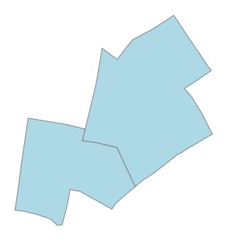

```python
ax = ox.project_gdf(nolibs_fishtown).plot(fc="lightblue", ec="gray")
ax.set_axis_off()
```

### Extract streets within these polygons

- Take the union of the polygons: `unary_union`
- Use `ox.graph_from_polygon()`

```python
nolibs_fishtown_outline = nolibs_fishtown.geometry.unary_union
nolibs_fishtown_outline
```

```python
type(nolibs_fishtown_outline)
```

```
shapely.geometry.polygon.Polygon
```

```python
# get the graph
G_nolibs_fishtown = ox.graph_from_polygon(nolibs_fishtown_outline, network_type='drive')
```

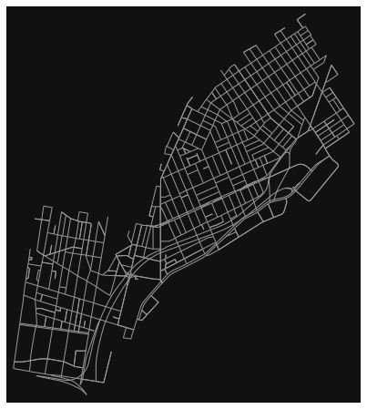

```python
# viola!
ox.plot_graph(ox.project_graph(G_nolibs_fishtown), node_size=0);
```

We could also use `unary_union.convex_hull`. This will be an encompassing polygon around any set of geometries.

```python
nolibs_fishtown.geometry.unary_union
```

```python
nolibs_fishtown.geometry.unary_union.convex_hull
```

## 1.5 Converting from a graph to a GeoDataFrame

Key function: `ox.graph_to_gdfs()` ([docs](https://osmnx.readthedocs.io/en/stable/osmnx.html?highlight=graph_to_gdf#osmnx.utils_graph.graph_to_gdfs))

You can get a GeoDataFrame for both the nodes (points) and edges (lines)

```python
# only get the edges
nolibs_edges = ox.graph_to_gdfs(G_nolibs_fishtown,
                                edges=True,
                                nodes=False)
```

```python
# we have lots of data associated with each edge!
nolibs_edges.head()
```

| u | v | key | osmid | oneway | name | highway | length | geometry | lanes | maxspeed | bridge | ref |
| --- | --- | --- | --- | --- | --- | --- | --- | --- | --- | --- | --- | --- |
| 109729430 | 109729453 | 0 | 12109175 | True | North 5th Street | residential | 117.685 | LINESTRING (-75.14637 39.96458, -75.14655 39.9... | NaN | NaN | NaN | NaN |
|  |  | 1 | 789845372 | True | North 5th Street | tertiary | 97.779 | LINESTRING (-75.14637 39.96458, -75.14627 39.9... | NaN | NaN | NaN | NaN |
| 109729453 | 109729801 | 0 | 789845372 | True | North 5th Street | tertiary | 32.185 | LINESTRING (-75.14617 39.96544, -75.14609 39.9... | NaN | NaN | NaN | NaN |
| 109729699 | 109811674 | 0 | [424804073, 121643778] | True | Callowhill Street | trunk | 135.768 | LINESTRING (-75.14724 39.95779, -75.14739 39.9... | 5 | 35 mph | NaN | NaN |
|  | 109729709 | 0 | [633770802, 41959235] | True | North 5th Street | secondary | 90.451 | LINESTRING (-75.14724 39.95779, -75.14722 39.9... | NaN | NaN | NaN | NaN |

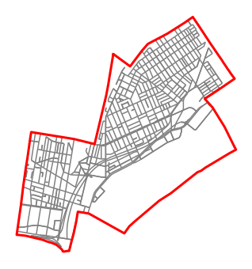

```python
# plot it like any old GeoDataFrame
ax = nolibs_edges.to_crs(epsg=3857).plot(color='gray')

# add the neighborhood boundaries
boundary = gpd.GeoSeries([nolibs_fishtown_outline], crs='EPSG:4326')
boundary.to_crs(epsg=3857).plot(ax=ax, facecolor='none', edgecolor='red', linewidth=3, zorder=2)

ax.set_axis_off()
```

## 1.6 What can we do with the graph?

- Network-based statistics
- Routing
- Street orientations
- Visualizing crashes

And much more: see the [OSMnx repository of Jupyter notebook examples](https://github.com/gboeing/osmnx-examples/tree/master/notebooks)

## Network statistics

We can use the `ox.basic_stats()` to get some basic network statistics

```python
ox.basic_stats(G_nolibs_fishtown)
```

```
{'n': 629,
 'm': 1229,
 'k_avg': 3.9077901430842608,
 'edge_length_total': 103561.27499999995,
 'edge_length_avg': 84.26466639544341,
 'streets_per_node_avg': 3.379968203497615,
 'streets_per_node_counts': {0: 0, 1: 18, 2: 2, 3: 342, 4: 259, 5: 6, 6: 2},
 'streets_per_node_proportions': {0: 0.0,
  1: 0.028616852146263912,
  2: 0.003179650238473768,
  3: 0.5437201907790143,
  4: 0.4117647058823529,
  5: 0.009538950715421303,
  6: 0.003179650238473768},
 'intersection_count': 611,
 'street_length_total': 86326.12299999999,
 'street_segment_count': 1009,
 'street_length_avg': 85.55611793855302,
 'circuity_avg': 1.0165046392413242,
 'self_loop_proportion': 0.0}
```

## Finding the shortest route

We can use the [`networkx`](https://networkx.org/documentation/networkx-2.5/index.html) package to do network-based calculations.

```python
import networkx as nx
```

Let's calculate the shortest route between [Frankford Hall](https://www.openstreetmap.org/node/3306921057) (a bar in Fishtown) and the [Spring Garden subway station](https://www.openstreetmap.org/node/5358095953):

```python
# Get all food and drink places within our Fishtown/No Libs polygon
fishtown_food_drink = ox.geometries_from_polygon(nolibs_fishtown_outline,
                                                 tags={"amenity": ["restaurant", "bar", "pub"]})
```

```python
fishtown_food_drink.head()
```

| element_type | osmid | addr:city | addr:housenumber | addr:postcode | addr:state | addr:street | amenity | brewery | craft | gnis:county_id | microbrewery | name | operator | restaurant | website | wikidata | wikipedia | geometry | opening_hours | phone | addr:housename | designation | cuisine | brand | brand:wikidata | brand:wikipedia | official_name | drive_in | outdoor_seating | … |
| --- | --- | --- | --- | --- | --- | --- | --- | --- | --- | --- | --- | --- | --- | --- | --- | --- | --- | --- | --- | --- | --- | --- | --- | --- | --- | --- | --- | --- | --- | --- |
| node | 357303425 | Philadelphia | 500 | 19123 | PA | Spring Garden Street | bar | yes | brewery | 101 | yes | Yards Brewing Company | Yards Brewing Company | yes | https://yardsbrewing.com/ | Q16903914 | en:Yards Brewing Company | POINT (-75.14712 39.96067) | NaN | NaN | NaN | NaN | NaN | NaN | NaN | NaN | NaN | NaN | NaN | … |
|  | 1475230378 | Philadelphia | 1001 | 19123 | NaN | North 2nd Street | bar | NaN | NaN | NaN | NaN | Gunner's Run | NaN | NaN | http://gunnersrun.com/ | NaN | NaN | POINT (-75.14002 39.96627) | Mo-Su 11:00-02:00 | 215-923-4600 | NaN | NaN | NaN | NaN | NaN | NaN | NaN | NaN | NaN | … |
|  | 1712028161 | Philadelphia | 901 | 19123 | NaN | North 2nd Street | restaurant | NaN | NaN | NaN | NaN | Standard Tap | NaN | NaN | standardtap.com | NaN | NaN | POINT (-75.14057 39.96416) | NaN | 215 -238-0630 | NaN | NaN | NaN | NaN | NaN | NaN | NaN | NaN | NaN | … |
|  | 1712044411 | NaN | NaN | NaN | NaN | thompson and susquahana | pub | NaN | NaN | NaN | NaN | Les n Doreen's Happy Tap | NaN | NaN | NaN | NaN | NaN | POINT (-75.12558 39.97373) | NaN | NaN | the happy tap | local dive | NaN | NaN | NaN | NaN | NaN | NaN | NaN | … |
|  | 1712050828 | NaN | 931 | 19123 | NaN | North 2nd Street | restaurant | NaN | NaN | NaN | NaN | Cantina Dos Segundos | NaN | NaN | https://www.cantinadossegundos.com/ | NaN | NaN | POINT (-75.14042 39.96483) | NaN | 215-629-0500 | NaN | NaN | mexican | NaN | NaN | NaN | NaN | NaN | NaN | … |

```python
# Select Frankford Hall based on the name column
frankford_hall = fishtown_food_drink.query("name == 'Frankford Hall'").squeeze()

# Get the x/y coordinates
frankford_hall_x = frankford_hall.geometry.x
frankford_hall_y = frankford_hall.geometry.y
```

```python
# Get all subway stations within our Fishtown/No Libs polygon
fishtown_subway_stops = ox.geometries_from_polygon(nolibs_fishtown_outline,
                                                   tags={"railway": "station"})
```

```python
# Select Spring Garden based on the name column
spring_garden_station = fishtown_subway_stops.query("name == 'Spring Garden'").squeeze()

# Get the x/y coordinates
spring_garden_x = spring_garden_station.geometry.x
spring_garden_y = spring_garden_station.geometry.y
```

Find the nearest nodes on our OSMnx graph:

```python
# Get the origin node
orig_node = ox.distance.nearest_nodes(G_nolibs_fishtown,  spring_garden_x, spring_garden_y)

# Get the destination node
dest_node = ox.distance.nearest_nodes(G_nolibs_fishtown, frankford_hall_x, frankford_hall_y)
```

Use `networkx` to find the shortest path between these graph nodes

```python
# get the shortest path --> just a list of node IDs
route = nx.shortest_path(G_nolibs_fishtown,
                         orig_node,
                         dest_node,
                         weight='length')
route
```

```
[110156961,
 110156976,
 110240102,
 110240110,
 110156990,
 110408354,
 110150984,
 110151026,
 109812663,
 3405862196,
 110274404,
 786190278,
 786189685,
 786189751,
 786190146,
 786189922,
 110227372,
 110549183,
 110207010,
 7738710013,
 7738710015,
 1479201402,
 1479201356,
 1479201380,
 1479201400,
 1479201370,
 7741504690,
 1479201401,
 110447508,
 109990294,
 109834418,
 109921057,
 109801805,
 109801799,
 109998370]
```

Use `ox.plot_graph_route()` to plot a graph and highlight a specific route

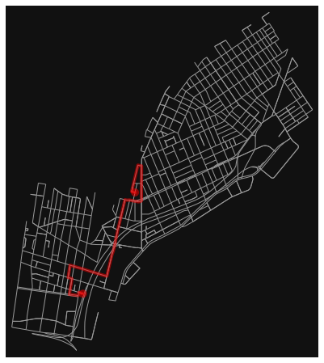

```python
ox.plot_graph_route(G_nolibs_fishtown, route, node_size=0);
```

## Part 2: Pandana

"Pandas Network Analysis - dataframes of network queries, quickly"

A complementary set of OSM-related features:

- Downloading OSM-based networks
- Extracting amenity data (so-called "Points of Interest")
- Calculating network-constrained distances
- [GitHub](https://github.com/UDST/pandana)
- [Jupyter Notebook Examples](https://github.com/UDST/pandana/tree/master/examples)
- [Documentation](http://udst.github.io/pandana/)

```python
import pandana as pnda
from pandana.loaders import osm
```

### Step 1: Get amenity data

Key function: `osm.node_query()`

- This will extract amenities within a given bounding box.
- Similar to the `ox.geometries_from_bbox()` function in OSMnx, but we slightly different syntax.

```python
osm.node_query?
```

Get the bounding box for Northern Liberties / Fishtown:

```python
boundary = nolibs_fishtown_outline.bounds
boundary
```

```
(-75.14891, 39.955458, -75.113226, 39.984757)
```

```python
[lng_min, lat_min, lng_max, lat_max] = boundary
```

```python
# query OSM
poi_df = osm.node_query(lat_min, lng_min, lat_max, lng_max)

# remove missing data
poi_df = poi_df.dropna(subset=['amenity'])
```

```python
poi_df.head()
```

| id | lat | lon | highway | traffic_signals | railway | old_ref | ref | noref | stop | crossing | disused:railway | ele | gnis:Class | gnis:County | gnis:County_num | gnis:ST_alpha | gnis:ST_num | gnis:id | import_uuid | is_in | name | place | wikidata | wikipedia | addr:city | addr:housenumber | addr:postcode | addr:street | opening_hours | … |
| --- | --- | --- | --- | --- | --- | --- | --- | --- | --- | --- | --- | --- | --- | --- | --- | --- | --- | --- | --- | --- | --- | --- | --- | --- | --- | --- | --- | --- | --- | --- |
| 357274893 | 39.972335 | -75.130176 | NaN | NaN | NaN | NaN | NaN | NaN | NaN | NaN | NaN | 7 | NaN | NaN | NaN | NaN | NaN | NaN | NaN | NaN | Adaire Alexander School | NaN | NaN | NaN | NaN | NaN | NaN | NaN | NaN | … |
| 357283515 | 39.976497 | -75.116743 | NaN | NaN | NaN | NaN | NaN | NaN | NaN | NaN | NaN | 4 | NaN | NaN | NaN | NaN | NaN | NaN | NaN | NaN | Maritime Academy Charter High School | NaN | NaN | NaN | NaN | NaN | NaN | NaN | NaN | … |
| 357288962 | 39.981243 | -75.126783 | NaN | NaN | NaN | NaN | NaN | NaN | NaN | NaN | NaN | 8 | NaN | NaN | NaN | NaN | NaN | NaN | NaN | NaN | Horatio B. Hackett School | NaN | NaN | NaN | NaN | NaN | NaN | NaN | NaN | … |
| 357297150 | 39.983189 | -75.141190 | NaN | NaN | NaN | NaN | NaN | NaN | NaN | NaN | NaN | 16 | NaN | NaN | NaN | NaN | NaN | NaN | NaN | NaN | McKinley William School | NaN | NaN | NaN | NaN | NaN | NaN | NaN | NaN | … |
| 357303425 | 39.960668 | -75.147121 | NaN | NaN | NaN | NaN | NaN | NaN | NaN | NaN | NaN | NaN | NaN | NaN | NaN | NaN | NaN | NaN | NaN | NaN | Yards Brewing Company | NaN | Q16903914 | en:Yards Brewing Company | Philadelphia | 500 | 19123 | Spring Garden Street | NaN | … |

```python
len(poi_df)
```

```
171
```

```python
poi_df[['lat', 'lon', 'amenity']].head(10)
```

| id | lat | lon | amenity |
| --- | --- | --- | --- |
| 357274893 | 39.972335 | -75.130176 | school |
| 357283515 | 39.976497 | -75.116743 | school |
| 357288962 | 39.981243 | -75.126783 | school |
| 357297150 | 39.983189 | -75.141190 | school |
| 357303425 | 39.960668 | -75.147121 | bar |
| 357373853 | 39.972874 | -75.127243 | school |
| 367962776 | 39.978845 | -75.118371 | fire_station |
| 1475159482 | 39.969869 | -75.144829 | place_of_worship |
| 1475229905 | 39.967481 | -75.139696 | disused |
| 1475230378 | 39.966270 | -75.140024 | bar |

### Explore the amenities in this region

For the full list of amenities, see the [OSM Wikipedia](https://wiki.openstreetmap.org/wiki/Key:amenity)

```python
chart = (
    alt.Chart(poi_df)
    .mark_bar()
    .encode(y=alt.Y("amenity", sort="-x"), x="count()", tooltip=["amenity", "count()"])
)

chart
```

[interactive chart not shown]

### Step 2: Create a Pandana network

- Key function: `pdna_network_from_bbox()`
- It takes a bounding box and returns the OSM network within that region.
- Multiple network types: 'walk' and 'drive'

```python
net = osm.pdna_network_from_bbox(
    lat_min, lng_min, lat_max, lng_max, network_type="walk"
)
```

```
Requesting network data within bounding box from Overpass API in 1 request(s)
Posting to http://www.overpass-api.de/api/interpreter with timeout=180, "{'data': '[out:json][timeout:180];(way["highway"]["highway"!~"motor|proposed|construction|abandoned|platform|raceway"]["foot"!~"no"]["pedestrians"!~"no"](39.95545800,-75.14891000,39.98475700,-75.11322600);>;);out;'}"
```

[output not shown]

### Step 3: Tell the network the location of amenities

Key function: `network.set_pois()`

- Today, we'll explore these four amenities: "restaurant", "bar", "school", "car_sharing"
- **IMPORTANT:** if you want to explore other amenities, you'll need to run the code below for your amenities of interest

```python
# sensible defaults
max_distance = 2000  # in meters
num_pois = 10  # only need the 10 nearest POI to each point in the network


AMENITIES = ["restaurant", "bar", "school", "car_sharing"]
for amenity in AMENITIES:

    # get the subset of amenities for this type
    pois_subset = poi_df[poi_df["amenity"] == amenity]

    # set the POI, using the longitude and latitude of POI
    net.set_pois(
        amenity, max_distance, num_pois, pois_subset["lon"], pois_subset["lat"]
    )
```

```python
# keyword arguments to pass for the matplotlib figure
bbox_aspect_ratio = (lat_max - lat_min) / (lng_max - lng_min)
fig_kwargs = {"facecolor": "w", "figsize": (10, 10 * bbox_aspect_ratio)}

# keyword arguments to pass for scatter plots
plot_kwargs = {"s": 20, "alpha": 0.9, "cmap": "viridis_r", "edgecolor": "none"}
```

### Step 4: Plot the walking distance to the nearest POI

For every point on the network, find the nth nearest POI, calculate the distance, and color that point according to the distance.

1. Use `network.nearest_poi()` to get distances from nodes to nearest POIs
2. Merge coordinates of network nodes with distances to nearest POIs
3. Plot the node coordinates, colored by distance to nth nearest POI

### 1. Use `network.nearest_poi()` to get distances from nodes to nearest POIs

```python
num_pois
```

```
10
```

```python
amenity = 'bar'
access = net.nearest_pois(distance=1000,
                          category=amenity,
                          num_pois=num_pois)
```

```python
access.head(n=20)
```

| id | 1 | 2 | 3 | 4 | 5 | 6 | 7 | 8 | 9 | 10 |
| --- | --- | --- | --- | --- | --- | --- | --- | --- | --- | --- |
| 103353219 | 1000.000000 | 1000.000000 | 1000.000000 | 1000.000000 | 1000.000000 | 1000.000000 | 1000.000000 | 1000.000000 | 1000.000000 | 1000.0 |
| 103357134 | 1000.000000 | 1000.000000 | 1000.000000 | 1000.000000 | 1000.000000 | 1000.000000 | 1000.000000 | 1000.000000 | 1000.000000 | 1000.0 |
| 103357139 | 1000.000000 | 1000.000000 | 1000.000000 | 1000.000000 | 1000.000000 | 1000.000000 | 1000.000000 | 1000.000000 | 1000.000000 | 1000.0 |
| 103407531 | 1000.000000 | 1000.000000 | 1000.000000 | 1000.000000 | 1000.000000 | 1000.000000 | 1000.000000 | 1000.000000 | 1000.000000 | 1000.0 |
| 103407534 | 1000.000000 | 1000.000000 | 1000.000000 | 1000.000000 | 1000.000000 | 1000.000000 | 1000.000000 | 1000.000000 | 1000.000000 | 1000.0 |
| 103417453 | 1000.000000 | 1000.000000 | 1000.000000 | 1000.000000 | 1000.000000 | 1000.000000 | 1000.000000 | 1000.000000 | 1000.000000 | 1000.0 |
| 103426172 | 1000.000000 | 1000.000000 | 1000.000000 | 1000.000000 | 1000.000000 | 1000.000000 | 1000.000000 | 1000.000000 | 1000.000000 | 1000.0 |
| 103426218 | 1000.000000 | 1000.000000 | 1000.000000 | 1000.000000 | 1000.000000 | 1000.000000 | 1000.000000 | 1000.000000 | 1000.000000 | 1000.0 |
| 103439886 | 1000.000000 | 1000.000000 | 1000.000000 | 1000.000000 | 1000.000000 | 1000.000000 | 1000.000000 | 1000.000000 | 1000.000000 | 1000.0 |
| 103449512 | 1000.000000 | 1000.000000 | 1000.000000 | 1000.000000 | 1000.000000 | 1000.000000 | 1000.000000 | 1000.000000 | 1000.000000 | 1000.0 |
| 103455424 | 1000.000000 | 1000.000000 | 1000.000000 | 1000.000000 | 1000.000000 | 1000.000000 | 1000.000000 | 1000.000000 | 1000.000000 | 1000.0 |
| 103455428 | 1000.000000 | 1000.000000 | 1000.000000 | 1000.000000 | 1000.000000 | 1000.000000 | 1000.000000 | 1000.000000 | 1000.000000 | 1000.0 |
| 109729330 | 549.151001 | 872.901001 | 1000.000000 | 1000.000000 | 1000.000000 | 1000.000000 | 1000.000000 | 1000.000000 | 1000.000000 | 1000.0 |
| 109729372 | 420.627014 | 744.377014 | 1000.000000 | 1000.000000 | 1000.000000 | 1000.000000 | 1000.000000 | 1000.000000 | 1000.000000 | 1000.0 |
| 109729430 | 456.679993 | 608.028015 | 610.737000 | 635.078003 | 635.078003 | 702.736023 | 713.599976 | 745.841003 | 932.004028 | 1000.0 |
| 109729453 | 554.469971 | 615.809998 | 639.916992 | 648.051025 | 705.817993 | 708.526978 | 732.867981 | 732.867981 | 839.302002 | 1000.0 |
| 109729661 | 480.838989 | 804.588989 | 1000.000000 | 1000.000000 | 1000.000000 | 1000.000000 | 1000.000000 | 1000.000000 | 1000.000000 | 1000.0 |
| 109729673 | 412.653015 | 736.403015 | 1000.000000 | 1000.000000 | 1000.000000 | 1000.000000 | 1000.000000 | 1000.000000 | 1000.000000 | 1000.0 |
| 109729699 | 306.233002 | 629.982971 | 919.973022 | 919.973022 | 1000.000000 | 1000.000000 | 1000.000000 | 1000.000000 | 1000.000000 | 1000.0 |
| 109729709 | 215.768005 | 539.518005 | 829.507996 | 829.507996 | 1000.000000 | 1000.000000 | 1000.000000 | 1000.000000 | 1000.000000 | 1000.0 |

### 2. Merge coordinates of network nodes with distances to nearest POIs

```python
net.nodes_df.head()
```

| id | x | y |
| --- | --- | --- |
| 103353219 | -75.115434 | 39.957472 |
| 103357134 | -75.114734 | 39.954193 |
| 103357139 | -75.113843 | 39.957221 |
| 103407531 | -75.120641 | 39.955889 |
| 103407534 | -75.119286 | 39.955627 |

```python
access.head()
```

| id | 1 | 2 | 3 | 4 | 5 | 6 | 7 | 8 | 9 | 10 |
| --- | --- | --- | --- | --- | --- | --- | --- | --- | --- | --- |
| 103353219 | 1000.0 | 1000.0 | 1000.0 | 1000.0 | 1000.0 | 1000.0 | 1000.0 | 1000.0 | 1000.0 | 1000.0 |
| 103357134 | 1000.0 | 1000.0 | 1000.0 | 1000.0 | 1000.0 | 1000.0 | 1000.0 | 1000.0 | 1000.0 | 1000.0 |
| 103357139 | 1000.0 | 1000.0 | 1000.0 | 1000.0 | 1000.0 | 1000.0 | 1000.0 | 1000.0 | 1000.0 | 1000.0 |
| 103407531 | 1000.0 | 1000.0 | 1000.0 | 1000.0 | 1000.0 | 1000.0 | 1000.0 | 1000.0 | 1000.0 | 1000.0 |
| 103407534 | 1000.0 | 1000.0 | 1000.0 | 1000.0 | 1000.0 | 1000.0 | 1000.0 | 1000.0 | 1000.0 | 1000.0 |

```python
# Merge the nodes and the distance to POIs
nodes = pd.merge(net.nodes_df, access, left_index=True, right_index=True)

# Make into a geodataframe
nodes = gpd.GeoDataFrame(
    nodes, geometry=gpd.points_from_xy(nodes["x"], nodes["y"]), crs="EPSG:4326"
)
```

```python
nodes.head()
```

| id | x | y | 1 | 2 | 3 | 4 | 5 | 6 | 7 | 8 | 9 | 10 | geometry |
| --- | --- | --- | --- | --- | --- | --- | --- | --- | --- | --- | --- | --- | --- |
| 103353219 | -75.115434 | 39.957472 | 1000.0 | 1000.0 | 1000.0 | 1000.0 | 1000.0 | 1000.0 | 1000.0 | 1000.0 | 1000.0 | 1000.0 | POINT (-75.11543 39.95747) |
| 103357134 | -75.114734 | 39.954193 | 1000.0 | 1000.0 | 1000.0 | 1000.0 | 1000.0 | 1000.0 | 1000.0 | 1000.0 | 1000.0 | 1000.0 | POINT (-75.11473 39.95419) |
| 103357139 | -75.113843 | 39.957221 | 1000.0 | 1000.0 | 1000.0 | 1000.0 | 1000.0 | 1000.0 | 1000.0 | 1000.0 | 1000.0 | 1000.0 | POINT (-75.11384 39.95722) |
| 103407531 | -75.120641 | 39.955889 | 1000.0 | 1000.0 | 1000.0 | 1000.0 | 1000.0 | 1000.0 | 1000.0 | 1000.0 | 1000.0 | 1000.0 | POINT (-75.12064 39.95589) |
| 103407534 | -75.119286 | 39.955627 | 1000.0 | 1000.0 | 1000.0 | 1000.0 | 1000.0 | 1000.0 | 1000.0 | 1000.0 | 1000.0 | 1000.0 | POINT (-75.11929 39.95563) |

### And now plot it!

Let's define a function to do this for us, since we'll repeat this plot multiple times

```python
def plot_walking_distance(net, amenity, distance=1000, n=1):
    """
    Plot the walking distance to the specified amenity
    """
    from mpl_toolkits.axes_grid1 import make_axes_locatable

    # subset of POI
    poi_subset = poi_df[poi_df["amenity"] == amenity]

    # get the distances to nearest num_pois POI
    access = net.nearest_pois(distance=1000, category=amenity, num_pois=num_pois)

    # merge node positions and distances to nearest PO
    nodes = pd.merge(net.nodes_df, access, left_index=True, right_index=True)
    nodes = gpd.GeoDataFrame(
        nodes, geometry=gpd.points_from_xy(nodes["x"], nodes["y"]), crs="EPSG:4326"
    )

    # Create the figure
    fig, ax = plt.subplots(figsize=(10, 10))
    divider = make_axes_locatable(ax)
    cax = divider.append_axes("right", size="5%", pad=0.1)

    # plot the distance to the nth nearest amenity
    ax = nodes.plot(ax=ax, cax=cax, column=nodes[n], legend=True, **plot_kwargs)

    # add the amenities as stars
    for i, row in poi_subset.iterrows():
        ax.scatter(row["lon"], row["lat"], color="red", s=100, marker="*")

    # format
    ax.set_facecolor("black")
    ax.figure.set_size_inches(fig_kwargs["figsize"])

    # set extent
    [xmin, ymin, xmax, ymax] = nodes.geometry.total_bounds
    ax.set_xlim(xmin, xmax)
    ax.set_ylim(ymin, ymax)

    return ax
```

### Evaluating amenity choice

The difference between maps to the nearest amenity and for example, the 5th nearest amenity tells us about the options consumers have

### Example: bars

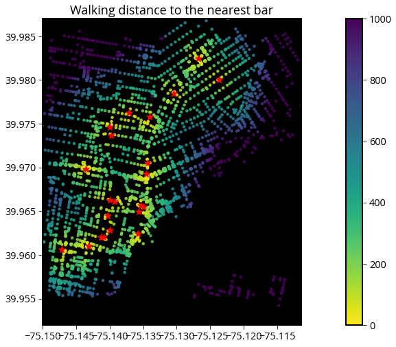

```python
ax = plot_walking_distance(net, "bar", n=1)
ax.set_title("Walking distance to the nearest bar", fontsize=18);
```

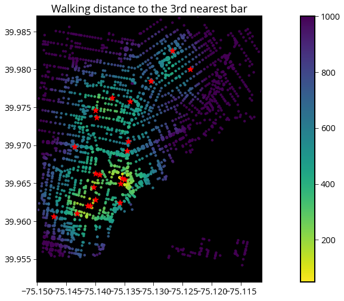

```python
ax = plot_walking_distance(net, "bar", n=3)
ax.set_title("Walking distance to the 3rd nearest bar", fontsize=18);
```

### Example: schools

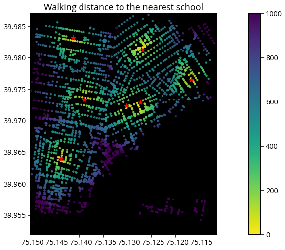

```python
ax = plot_walking_distance(net, "school", n=1)
ax.set_title("Walking distance to the nearest school", fontsize=18);
```

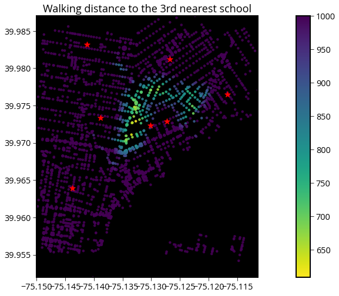

```python
ax = plot_walking_distance(net, "school", n=3)
ax.set_title("Walking distance to the 3rd nearest school", fontsize=18);
```

### Example: restaurants

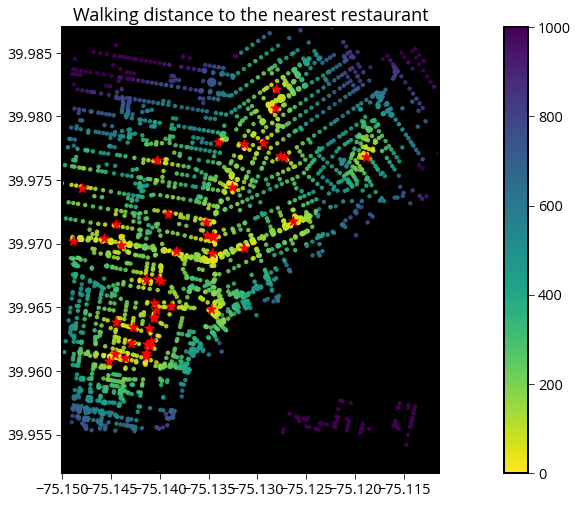

```python
ax = plot_walking_distance(net, "restaurant", n=1)
ax.set_title("Walking distance to the nearest restaurant", fontsize=18);
```

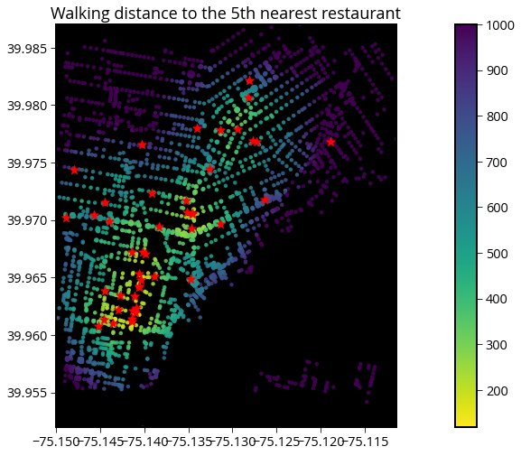

```python
ax = plot_walking_distance(net, "restaurant", n=5)
ax.set_title("Walking distance to the 5th nearest restaurant", fontsize=18);
```

### Example: car sharing

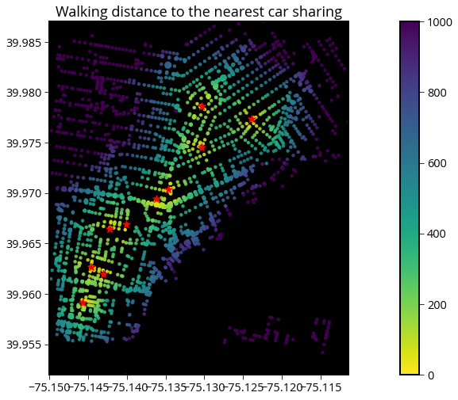

```python
ax = plot_walking_distance(net, "car_sharing", n=1)
ax.set_title("Walking distance to the nearest car sharing", fontsize=18);
```

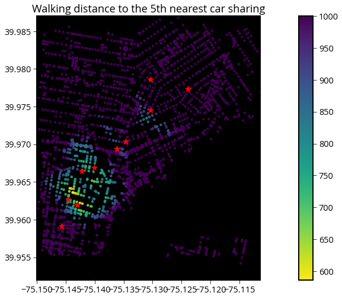

```python
ax = plot_walking_distance(net, "car_sharing", n=5)
ax.set_title("Walking distance to the 5th nearest car sharing", fontsize=18);
```

## At-home exercise: Explore amenities in the neighborhood of your choice

Many, many more amenities are logged throughout the city. Pick your favorite neighborhood and explore.

See [this page](https://wiki.openstreetmap.org/wiki/Key:amenity) for the full list of amenities.

**Final project idea**: With this kind of analysis, you can look at amenity-based influence in housing, neighborhood selection, etc. or something similar to the [Walk Score](https://www.walkscore.com/).